# Adult hindleg length - Heritability estimate and GWAS

Caelinn James

10 April 2021

**Written for R 4.0.2, last updated 31/07/21**

### Load packages

```r
library(RODBC)
library(data.table)
library(stringr)
library(splitstackshape)
library(qqman)
```

### Connect to the database

Note that from database front end version 2.22, it is important to click “Make R Friendly” in the queries section behind running the analysis, or loading the pedigree will not work (will not work at all for prior front end versions)

```r
dv <- "C:/Users/s1944058/Documents/Sheep/Database/SoaySheep2.30.accdb"
con <- odbcConnectAccess2007(dv)
tbls <- sqlTables(con)
capturedata <- sqlFetch(con,"CaptureData")
sheep <- sqlFetch(con,"sys_SheepPlusBirthInfo")
```

Check to see if the files have loaded correctly (don’t worry about negative IDs or lots of NAs)…  
First the capture data file….

```r
head(capturedata)
```

```
##   CapRef CatchEventRef Trap   ID   Tag Retag CapYear CapMonth CapDay Time
## 1      2            NA <NA> 1540 NY195  <NA>    1985        8     15 <NA>
## 2      3            NA <NA> 1546 NY201  <NA>    1985        8     15 <NA>
## 3      4            NA <NA> 1055 OK001  <NA>    1985        8     12 <NA>
## 4      5            NA <NA>   94 SY143 OY001    1985        8     12 <NA>
## 5      6            NA <NA>  546 SB068 OB001    1985        8     12 <NA>
## 6      7            NA <NA> 1201 SG035 OG001    1985        8     12 <NA>
##   Measurer LiveMeasure Weight Foreleg Hindleg HornLen HornCirc Horn01 Horn02
## 1     <NA>           1    9.7      NA      NA      NA       NA     NA     NA
## 2     <NA>           1   12.5      NA      NA      NA       NA     NA     NA
## 3     <NA>           1   36.5      NA      NA      NA       NA     NA     NA
## 4     <NA>           1   38.4      NA      NA     615       NA     NA     NA
## 5     <NA>           1   25.0      NA      NA      NA       NA     NA     NA
## 6     <NA>           1   23.3      NA      NA     296       NA     NA     NA
##   Horn03 Horn04 Horn05 Horn06 Horn07 Horn08 Horn09 Horn10 LHbroken RHbroken
```

[output cut: 48 more lines]

Then the sheep file…

```r
head(sheep)
```

```
##      ID BirthRef MumSource Status Sex Coat Horn BirthYear BirthMonth BirthDay
## 1 -2644    11143         3  Dummy   2   NA   NA        NA         NA       NA
## 2 -2643       NA        NA  Dummy   2   NA   NA        NA         NA       NA
## 3 -2642    11142         3  Dummy   2   NA   NA        NA         NA       NA
## 4 -2641       NA        NA  Dummy   2   NA   NA        NA         NA       NA
## 5 -2640       NA        NA  Dummy   2   NA   NA        NA         NA       NA
## 6 -2639       NA        NA  Dummy   2   NA   NA        NA         NA       NA
##   MumID BirthWt CapAge BirthEasting BirthNorthing SibCount SibNoObserved TwinID
## 1  4106      NA     NA           NA            NA        0             0     NA
## 2    NA      NA     NA           NA            NA        0             0     NA
## 3 10114      NA     NA           NA            NA        0             0     NA
## 4    NA      NA     NA           NA            NA        0             0     NA
## 5    NA      NA     NA           NA            NA        0             0     NA
## 6    NA      NA     NA           NA            NA        0             0     NA
##   TripletID DeathYear DeathMonth DeathDay DeathType DeathEasting DeathNorthing
## 1        NA        NA         NA       NA        NA           NA            NA
## 2        NA        NA         NA       NA        NA           NA            NA
## 3        NA        NA         NA       NA        NA           NA            NA
## 4        NA        NA         NA       NA        NA           NA            NA
## 5        NA        NA         NA       NA        NA           NA            NA
## 6        NA        NA         NA       NA        NA           NA            NA
##   InCleitDeath
## 1           NA
## 2           NA
## 3           NA
## 4           NA
## 5           NA
## 6           NA
```

### Filter the data

We are only interested in looking at capture events that happened in August and to adults

```r
capturedataadult <- merge(sheep,capturedata,by.x="ID")
capturedataadult<- capturedataadult[which(capturedataadult$CapMonth == 8),]
capturedataadult <- capturedataadult[which(capturedataadult$CapYear > (capturedataadult$BirthYear +1)),]
```

Now, only include records of capture events that measured the hindleg.

```r
capturedataadult <- capturedataadult[!is.na(capturedataadult$Hindleg),]
```

Calculate the age of the sheep for their hindleg measure

```r
capturedataadult$Age <- capturedataadult$CapYear - capturedataadult$BirthYear
capturedataadult$Age <- as.numeric(capturedataadult$Age)
```

```r
Villdens <- sqlFetch(con,"HirtaVillPop")
capturedataadult <- merge(capturedataadult,Villdens[,c("VillTotal","Year")],by.x="BirthYear",by.y="Year",all.x=T)
```

```r
SNPs_50K <- read.table("~/Documents/Sheep/50KSNP/Plates_1to87_QC3.fam")
capturedataadult <- capturedataadult[which(capturedataadult$ID %in% SNPs_50K$V2),]
SNPs_HD <- read.table("~/Documents/Sheep/HDSNP/sheep_geno_imputed_oar31_17052020.fam")
capturedataadult <- capturedataadult[which(capturedataadult$ID %in% SNPs_HD$V2),]
```

This leaves us with **3592** records from **1194** individuals, and the following distribution of leg lengths:

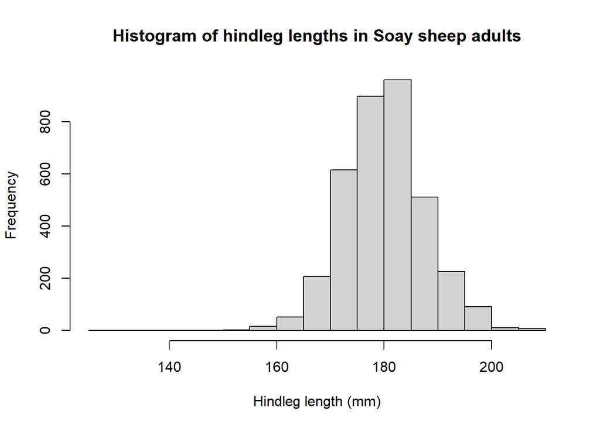

```r
hist(as.numeric(capturedataadult$Hindleg),xlab="Hindleg length (mm)",main="Histogram of hindleg lengths in Soay sheep adults")
```

We will now save a list of phenotypes, fixed effects and random effects.

```r
AdulthindLegPhenotypes <- cbind(rep(1,nrow(capturedataadult)),as.numeric(as.character(capturedataadult$CapRef)),as.character(capturedataadult$ID),as.character(capturedataadult$Hindleg))

AdulthindLegAssoc <- cbind(rep(1,nrow(capturedataadult)),as.numeric(as.character(capturedataadult$CapRef)),capturedataadult$Sex)

AdulthindLegQAssoc <-cbind(rep(1,nrow(capturedataadult)),as.numeric(as.character(capturedataadult$CapRef)),capturedataadult$VillTotal,capturedataadult$Age)

AdulthindLegRandom <-cbind(rep(1,nrow(capturedataadult)),as.numeric(as.character(capturedataadult$CapRef)),capturedataadult$CapYear,as.character(capturedataadult$ID))
colnames(AdulthindLegRandom) <- c("FID","IID","CapYear","ID")


write.table(AdulthindLegPhenotypes,file="~/Documents/Sheep/R/Hindleg/AdultHindLegPhenotypes.txt",row.names = F,col.names = F,quote = F)

write.table(AdulthindLegAssoc,file="~/Documents/Sheep/R/Hindleg/AdultHindLegAssoc.txt",row.names = F,col.names = F,quote = F)

write.table(AdulthindLegQAssoc,file="~/Documents/Sheep/R/Hindleg/AdultHindLegQAssoc.txt",row.names = F,col.names = F,quote = F)

write.table(AdulthindLegRandom,file="~/Documents/Sheep/R/Hindleg/AdultHindLegRandom.txt",row.names = F,col.names = T,quote = F)
```

## Prep the genotype files

> #!/bin/sh  
> #$ -cwd  
> #$ -l h_rt=0:30:00  
> #$ -pe sharedmem 1  
> #$ -l h_vmem=50G

> sort -k 3,3 AdultHindlegPhenotypes.txt > Pheno150K.txt  
> awk ‘($2 >0)’ ../InputData/Plates_1to87_QC3.ped > Ped150K.ped  
> sort -k 2,2 Ped150K.ped > Ped250K.ped  
> join -1 3 -2 2 Pheno150K.txt Ped250K.ped > Ped350K.ped  
> cut -d ’ ’ -f 1,4,5 --complement Ped350K.ped > AdultHindleg50K.ped

> sort -k 3,3 AdultHindlegPhenotypes.txt > Pheno1HD.txt  
> awk ‘($2 >0)’ ../InputData/sheep_geno_imputed_oar31_17052020.ped > Ped1HD.ped  
> sort -k 2,2 Ped1HD.ped > Ped2HD.ped  
> join -1 3 -2 2 Pheno1HD.txt Ped2HD.ped > Ped3HD.ped  
> cut -d ’ ’ -f 1,4,5 --complement Ped3HD.ped > AdultHindlegHD.ped

## Heritability Estimates

### 50K

> #!/bin/sh  
> #$ -cwd  
> #$ -l h_rt=1:00:00  
> #$ -pe sharedmem 1  
> #$ -l h_vmem=100G  
> #$ -M s1944058@sms.ed.ac.uk  
> #$ -m baes  
> . /etc/profile.d/modules.sh

> module load igmm/apps/dissect/1.15.2c  
> module load igmm/apps/plink/1.90b4

> plink –file ../InputData/Plates_1to87_QC3 --ped AdultHindleg50K.ped --sheep --not-chr 0,X --make-bed --out 50K/AdultHindleg50K

> mpirun -np 8 dissect.mpich --reml --bfile 50K/AdultHindleg50K --pheno AdultHindlegPhenotypes.txt --pheno-col 2 --blue --covar AdultHindlegAssoc.txt --qcovar AdultHindlegQAssoc.txt --random-effects AdultHindlegRandom.txt --random-effects-cols 1 2 --out 50K/AdultHindLeg_50K_H2

> if [[ -f 50K/AdultHindLeg_50K_H2.badsnps ]]  
> then  
> plink --bfile ../InputData/Plates_1to87_QC3 --sheep --exclude 50K/AdultHindLeg_50K_H2.badsnps --make-bed --out 50K/AdultHindLeg_50K_H2

> mpirun -np 8 dissect.mpich --reml --bfile 50K/AdultHindLeg_50K_H2 --pheno AdultHindlegPhenotypes.txt --pheno-col 2 --blue --covar AdultHindlegAssoc.txt --qcovar AdultHindlegQAssoc.txt --random-effects AdultHindlegRandom.txt --random-effects-cols 1 2 --out 50K/AdultHindLeg_50K_H2  
> fi

> mpirun -np 8 dissect.mpich --reml --bfile 50K/AdultHindleg50K --pheno AdultHindlegPhenotypes.txt --pheno-col 2 --blue --random-effects AdultHindlegRandom.txt --random-effects-cols 1 2 --out 50K/AdultHindLeg_50K_TotalPhenotypeVariance

> if [[ -f 50K/AdultHindLeg_50K_TotalPhenotypeVariance.badsnps ]]  
> then  
> plink --bfile ../InputData/Plates_1to87_QC3 --sheep --exclude 50K/AdultHindLeg_50K_TotalPhenotypeVariance.badsnps --make-bed --out 50K/AdultHindLeg_50K_TotalPhenotypeVariance

> mpirun -np 8 dissect.mpich --reml --bfile 50K/AdultHindLeg_50K_TotalPhenotypeVariance --pheno AdultHindlegPhenotypes.txt --pheno-col 2 --blue --random-effects AdultHindlegRandom.txt --random-effects-cols 1 2 --out 50K/AdultHindLeg_50K_TotalPhenotypeVariance  
> fi

```r
FixedEffects_50K
```

```
##         NAME       BETA        STD
## 1        Sex 8.42028000 0.39150500
## 2 Population 0.00230257 0.00170248
## 3        Age 0.11524500 0.02874300
```

```r
RandomEffects_50K
```

```
##                            NAME     BETA       STD
## 1:                  Var(GRM_p1)  19.9532   2.51223
## 2:              Var(CapYear_p1)    1.303  0.438004
## 3:                   Var(ID_p1)  18.1833    1.6567
## 4:                    Var(E_p1)  7.63645  0.221898
## 5: Var(GRM_p1)/Var(Phenotype_1) 0.423851 0.0417841
```

### HD

> #!/bin/sh  
> #$ -cwd  
> #$ -l h_rt=1:00:00  
> #$ -pe sharedmem 1  
> #$ -l h_vmem=100G  
> #$ -M s1944058@sms.ed.ac.uk  
> #$ -m baes  
> . /etc/profile.d/modules.sh

> module load igmm/apps/dissect/1.15.2c  
> module load igmm/apps/plink/1.90b4

> plink –file ../InputData/sheep_geno_imputed_oar31_17052020 --ped AdultHindlegHD.ped --sheep --not-chr 0,X --make-bed --out HD/AdultHindlegHD

> mpirun -np 8 dissect.mpich --reml --bfile HD/AdultHindlegHD --pheno AdultHindlegPhenotypes.txt --pheno-col 2 --blue --covar AdultHindlegAssoc.txt --qcovar AdultHindlegQAssoc.txt --random-effects AdultHindlegRandom.txt --random-effects-cols 1 2 --out HD/AdultHindLeg_HD_H2

> if [[ -f HD/AdultHindLeg_HD_H2.badsnps ]]  
> then  
> plink --bfile ../InputData/Plates_1to87_QC3 --sheep --exclude HD/AdultHindLeg_HD_H2.badsnps --make-bed --out HD/AdultHindLeg_HD_H2

> mpirun -np 8 dissect.mpich --reml --bfile HD/AdultHindLeg_HD_H2 --pheno AdultHindlegPhenotypes.txt --pheno-col 2 --blue --covar AdultHindlegAssoc.txt --qcovar AdultHindlegQAssoc.txt --random-effects AdultHindlegRandom.txt --random-effects-cols 1 2 --out HD/AdultHindLeg_HD_H2  
> fi

> mpirun -np 8 dissect.mpich --reml --bfile HD/AdultHindlegHD --pheno AdultHindlegPhenotypes.txt --pheno-col 2 --blue --random-effects AdultHindlegRandom.txt --random-effects-cols 1 2 --out HD/AdultHindLeg_HD_TotalPhenotypeVariance

> if [[ -f HD/AdultHindLeg_HD_TotalPhenotypeVariance.badsnps ]]  
> then  
> plink --bfile ../InputData/Plates_1to87_QC3 --sheep --exclude HD/AdultHindLeg_HD_TotalPhenotypeVariance.badsnps --make-bed --out HD/AdultHindLeg_HD_TotalPhenotypeVariance

> mpirun -np 8 dissect.mpich --reml --bfile HD/AdultHindLeg_HD_TotalPhenotypeVariance --pheno AdultHindlegPhenotypes.txt --pheno-col 2 --blue --random-effects AdultHindlegRandom.txt --random-effects-cols 1 2 --out HD/AdultHindLeg_HD_TotalPhenotypeVariance  
> fi

```r
FixedEffects_HD
```

```
##         NAME       BETA       STD
## 1        Sex 8.41260000 0.3898620
## 2 Population 0.00249734 0.0016950
## 3        Age 0.11972400 0.0288946
```

```r
RandomEffects_HD
```

```
##                            NAME     BETA       STD
## 1:                  Var(GRM_p1)  20.7464   2.53521
## 2:              Var(CapYear_p1)  1.36056  0.460112
## 3:                   Var(ID_p1)   17.222   1.63988
## 4:                    Var(E_p1)  7.63748  0.221933
## 5: Var(GRM_p1)/Var(Phenotype_1) 0.441728 0.0417542
```

### GWAS

> #!/bin/sh  
> #$ -cwd  
> #$ -l h_rt=2:00:00  
> #$ -pe sharedmem 1  
> #$ -l h_vmem=200G  
> #$ -t 1-26  
> #$ -tc 5  
> #$ -M s1944058@sms.ed.ac.uk  
> #$ -m baes  
> . /etc/profile.d/modules.sh

> module load igmm/apps/dissect/1.15.2c  
> module load igmm/apps/plink/1.90b4

> i=$_TASK_ID

> plink --bfile ../InputData/Plates_1to87_QC3 --ped AdultHindleg50K.ped --sheep --not-chr ${i},X --keep AdultHindlegPhenotypes.txt --make-bed --out 50K/NoChr${i}

> mpirun -np 8 dissect.mpich --make-grm --bfile 50K/NoChr${i} --out 50K/NoChr${i}_GRM

> echo "50K/Chr${i} 50K/NoChr${i}_GRM" > 50K/GWAS_GRM${i}.txt

> plink --bfile ../InputData/Plates_1to87_QC3 --ped AdultHindleg50K.ped --sheep --chr ${i} --keep AdultHindlegPhenotypes.txt --make-bed --out 50K/Chr${i}

> if [[ -f 50K/NoChr${i}_GRM.badsnps ]]  
> then  
> plink --bfile 50K/NoChr${i} --sheep --exclude 50K/NoChr${i}_GRM.badsnps --make-bed --out 50K/NoChr${i}_2

> mpirun -np 8 dissect.mpich --make-grm --bfile 50K/NoChr${i}_2 --out 50K/NoChr${i}_GRM

> fi

> mpirun -np 8 dissect.mpich --gwas --bfile-grm-list 50K/GWAS_GRM${i}.txt --pheno AdultHindlegPhenotypes.txt --pheno-col 2 --covar AdultHindlegAssoc.txt --qcovar AdultHindlegQAssoc.txt --random-effects AdultHindlegRandom.txt --random-effects-cols 1 2 --out 50K/AdultHindLeg_50K_GWAS_Chr${i}

> if [[ -f 50K/AdultHindLeg_50K_GWAS_Chr${i}.badsnps ]]  
> then  
> plink --bfile 50K/Chr${i} --sheep --exclude 50K/AdultHindLeg_50K_GWAS_Chr${i}.badsnps --make-bed --out 50K/Chr${i}_2

> echo "50K/Chr${i}_2 50K/NoChr${i}_GRM" > 50K/GWAS_GRM${i}.txt

> mpirun -np 8 dissect.mpich --gwas --bfile-grm-list 50K/GWAS_GRM${i}.txt --pheno AdultHindlegPhenotypes.txt --pheno-col 2 --covar AdultHindlegAssoc.txt --qcovar AdultHindlegQAssoc.txt --random-effects AdultHindlegRandom.txt --random-effects-cols 1 2 --out 50K/AdultHindLeg_50K_GWAS_Chr${i}  
> fi

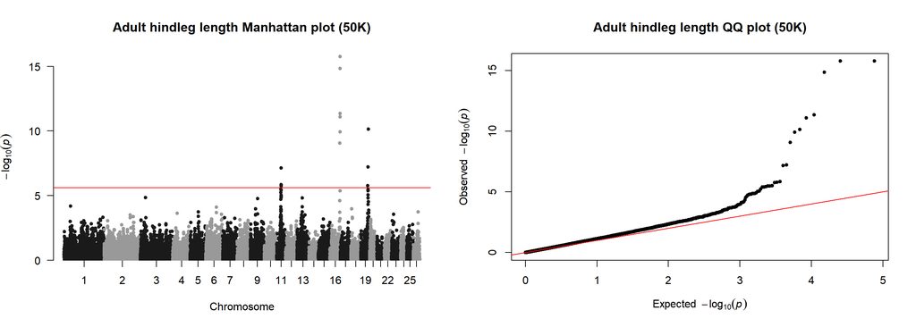

```r
files = list.files(pattern="AdultHindLeg_50K_GWAS_Chr",recursive=TRUE)

SNPresults = do.call(rbind, lapply(files, function(x) read.table(x,header=T)))
SNPresults$Effect <- SNPresults$STDEV*SNPresults$STDEV*SNPresults$BETA*SNPresults$BETA

bimFile <- read.table("C:/Users/s1944058/Documents/Sheep/50KSNP/Plates_1to87_QC3.bim",header=F)

GWAS50KResults <- merge(bimFile,SNPresults[,c("SNP","PV","Effect"),],by.x="V2",by.y="SNP",all.x=FALSE,all.y=TRUE)
colnames(GWAS50KResults) <- c("SNP","Chr","V3","Pos","Ref","Minor","PV","Effect")
GWAS50KResults$Chr <- as.numeric(GWAS50KResults$Chr)
par(mfrow=c(1,2))
manhattan(GWAS50KResults,chr="Chr",bp="Pos",p="PV",snp="SNP", main = "Adult hindleg length Manhattan plot (50K)", genomewideline = -log10(0.05/20082),suggestiveline = FALSE)
qq(GWAS50KResults$PV,main="Adult hindleg length QQ plot (50K)")
```

```r
SNPs <- GWAS50KResults[which(GWAS50KResults$PV < (0.05/20082) ),c("Chr","Pos","SNP","PV","Effect")]
SNPs[order(SNPs$PV),]
```

```
##       Chr      Pos              SNP         PV    Effect
## 29797  16 69679810         s22142.1 1.7235e-16 0.1652423
## 29955  16 69726554         s23172.1 1.7235e-16 0.1652423
## 36280  16 69135141         s63944.1 1.4298e-15 0.1542447
## 29586  16 69657258         s20693.1 4.4451e-12 0.3902751
## 34660  16 70710282         s53565.1 8.2968e-12 0.2241360
## 37908  19 52470202         s74894.1 7.1599e-11 0.3506061
## 8473   16 69490404 OAR16_75450521.1 1.1943e-10 0.2477053
## 8469   16 68454044 OAR16_74353353.1 8.5726e-10 0.0533610
## 10280  19 50612222 OAR19_53216371.1 6.0035e-08 0.2483029
## 4755   11 30811134 OAR11_32693010.1 7.0758e-08 0.5419315
## 4750   11 30422053 OAR11_32301525.1 1.3969e-06 0.4484043
## 29255  19 47388307         s18450.1 1.6748e-06 0.1607248
## 4754   11 30747367 OAR11_32628142.1 1.7894e-06 0.4381063
```

### Imputed SNP data

> #!/bin/sh  
> #$ -cwd  
> #$ -l h_rt=3:00:00  
> #$ -pe sharedmem 1  
> #$ -l h_vmem=200G  
> #$ -t 1-26  
> #$ -tc 5  
> #$ -M s1944058@sms.ed.ac.uk  
> #$ -m baes  
> . /etc/profile.d/modules.sh

> module load igmm/apps/dissect/1.15.2c  
> module load igmm/apps/plink/1.90b4

> i=$_TASK_ID

> plink --bfile ../InputData/sheep_geno_imputed_oar31_17052020 --ped AdultHindlegHD.ped --sheep --not-chr ${i},X --keep AdultHindlegPhenotypes.txt --make-bed --out HD/NoChr${i}

> mpirun -np 8 dissect.mpich --make-grm --bfile HD/NoChr${i} --out HD/NoChr${i}_GRM

> echo "HD/Chr${i} HD/NoChr${i}_GRM" > HD/GWAS_GRM${i}.txt

> plink --bfile ../InputData/sheep_geno_imputed_oar31_17052020 --ped AdultHindlegHD.ped --sheep --chr ${i} --keep AdultHindlegPhenotypes.txt --make-bed --out HD/Chr${i}

> if [[ -f HD/NoChr${i}_GRM.badsnps ]]  
> then  
> plink --bfile HD/NoChr${i} --sheep --exclude HD/NoChr${i}_GRM.badsnps --make-bed --out HD/NoChr${i}_2

> mpirun -np 8 dissect.mpich --make-grm --bfile HD/NoChr${i}_2 --out HD/NoChr${i}_GRM

> fi

> mpirun -np 8 dissect.mpich --gwas --bfile-grm-list HD/GWAS_GRM${i}.txt --pheno AdultHindlegPhenotypes.txt --pheno-col 2 --covar AdultHindlegAssoc.txt --qcovar AdultHindlegQAssoc.txt --random-effects AdultHindlegRandom.txt --random-effects-cols 1 2 --out HD/AdultHindLeg_HD_GWAS_Chr${i}

> if [[ -f HD/AdultHindLeg_HD_GWAS_Chr${i}.badsnps ]]  
> then  
> plink --bfile HD/Chr${i} --sheep --exclude HD/AdultHindLeg_HD_GWAS_Chr${i}.badsnps --make-bed --out HD/Chr${i}_2

> echo "HD/Chr${i}_2 HD/NoChr${i}_GRM" > HD/GWAS_GRM${i}.txt

> mpirun -np 8 dissect.mpich --gwas --bfile-grm-list HD/GWAS_GRM${i}.txt --pheno AdultHindlegPhenotypes.txt --pheno-col 2 --covar AdultHindlegAssoc.txt --qcovar AdultHindlegQAssoc.txt --random-effects AdultHindlegRandom.txt --random-effects-cols 1 2 --out HD/AdultHindLeg_HD_GWAS_Chr${i}  
> fi

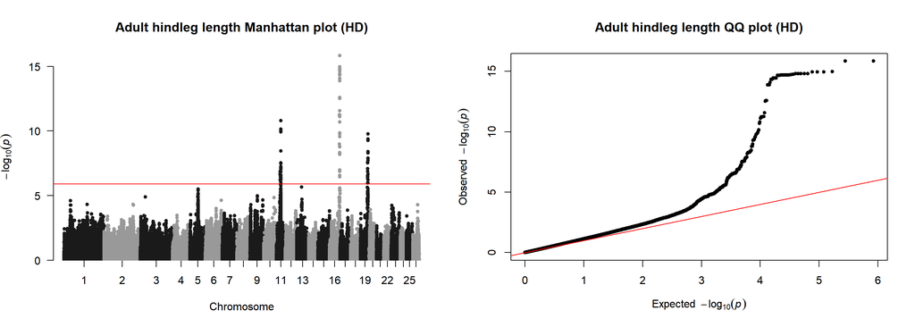

```r
files = list.files(pattern="AdultHindLeg_HD_GWAS_Chr",recursive=TRUE)

SNPresults = do.call(rbind, lapply(files, function(x) read.table(x,header=T)))
SNPresults$Effect <- SNPresults$STDEV*SNPresults$STDEV*SNPresults$BETA*SNPresults$BETA

bimFile <- read.table("C:/Users/s1944058/Documents/Sheep/HDSNP/sheep_geno_imputed_oar31_17052020.bim",header=F)

GWASHDResults <- merge(bimFile,SNPresults[,c("SNP","PV","Effect"),],by.x="V2",by.y="SNP",all.x=FALSE,all.y=TRUE)
colnames(GWASHDResults) <- c("SNP","Chr","V3","Pos","Ref","Minor","PV","Effect")
GWASHDResults$Chr <- as.numeric(GWASHDResults$Chr)
par(mfrow=c(1,2))
manhattan(GWASHDResults,chr="Chr",bp="Pos",p="PV",snp="SNP", main = "Adult hindleg length Manhattan plot (HD)", genomewideline = -log10(0.05/39149),suggestiveline = FALSE)
qq(GWASHDResults$PV,main="Adult hindleg length QQ plot (HD)")
```

```r
SNPs <- GWASHDResults[which(GWASHDResults$PV < (0.05/39149) ),c("Chr","Pos","SNP","PV","Effect")]
SNPs[order(SNPs$PV),]
```

```
##        Chr      Pos                 SNP         PV     Effect
## 410503  16 69679810            s22142.1 1.4480e-16 0.16524225
## 410666  16 69726554            s23172.1 1.4480e-16 0.16524225
## 144588  16 70412884 oar3_OAR16_70412884 1.0750e-15 0.15752961
## 144488  16 69943027 oar3_OAR16_69943027 1.1222e-15 0.15752961
## 144491  16 69951030 oar3_OAR16_69951030 1.1222e-15 0.15752961
## 144468  16 69848663 oar3_OAR16_69848663 1.1426e-15 0.15752961
## 144667  16 71032937 oar3_OAR16_71032937 1.5110e-15 0.16104972
## 144668  16 71034382 oar3_OAR16_71034382 1.5110e-15 0.16104972
## 144669  16 71034756 oar3_OAR16_71034756 1.5110e-15 0.16104972
## 144670  16 71035892 oar3_OAR16_71035892 1.5110e-15 0.16104972
## 144601  16 70480624 oar3_OAR16_70480624 1.5896e-15 0.12927620
## 144689  16 71129444 oar3_OAR16_71129444 1.7205e-15 0.16104972
## 417154  16 69135141            s63944.1 1.9304e-15 0.15424471
## 144439  16 69686720 oar3_OAR16_69686720 2.0775e-15 0.15327225
```

[output cut: 142 more lines]

## **FINAL RESULTS**

### 50K

```r
RandomEffects_50K[nrow(RandomEffects_50K),]
```

```
##                            NAME     BETA       STD
## 1: Var(GRM_p1)/Var(Phenotype_1) 0.423851 0.0417841
```

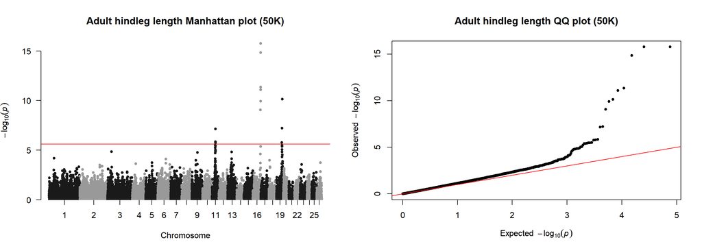

```r
par(mfrow=c(1,2))
manhattan(GWAS50KResults,chr="Chr",bp="Pos",p="PV",snp="SNP", main = "Adult hindleg length Manhattan plot (50K)", genomewideline = -log10(0.05/20082),suggestiveline = FALSE)
qq(GWAS50KResults$PV,main="Adult hindleg length QQ plot (50K)")
```

### HD

```r
RandomEffects_HD[nrow(RandomEffects_HD),]
```

```
##                            NAME     BETA       STD
## 1: Var(GRM_p1)/Var(Phenotype_1) 0.441728 0.0417542
```

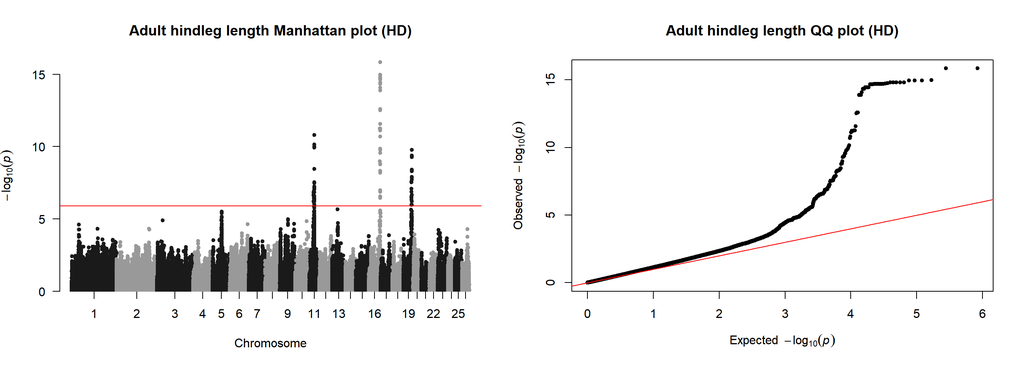

```r
par(mfrow=c(1,2))
manhattan(GWASHDResults,chr="Chr",bp="Pos",p="PV",snp="SNP", main = "Adult hindleg length Manhattan plot (HD)", genomewideline = -log10(0.05/39149),suggestiveline = FALSE)
qq(GWASHDResults$PV,main="Adult hindleg length QQ plot (HD)")
```